##### AI TECH - Akademia Innowacyjnych Zastosowań Technologii Cyfrowych. Programu Operacyjnego Polska Cyfrowa na lata 2014-2020

# Przykład 3 DO LABORATORIUM 5

# Tomasz Neumann

### Klasyfikacja przy użyciu Keras na zbiorze CIFAR-10 za pomocą prostej sieci neuronowej

[figure not shown]

Projekt współfinansowany ze środków Unii Europejskiej w ramach Europejskiego Funduszu Rozwoju Regionalnego Program Operacyjny Polska Cyfrowa na lata 2014-2020, Oś Priorytetowa nr 3 "Cyfrowe kompetencje społeczeństwa" Działanie nr 3.2 "Innowacyjne rozwiązania na rzecz aktywizacji cyfrowej" Tytuł projektu: „Akademia Innowacyjnych Zastosowań Technologii Cyfrowych (AI Tech)”

# 5. Przykład 3

Keras to wyspecjalizowany, przeznaczony do uczenia głębokiego interfejs API, za pomocą którego możemy z łatwością tworzyć, uczyć, oceniać i uruchamiać wszystkie rodzaje sieci neuronowych. W tym celu stworzymy klasyfikujący perceptron, który będzie pracował na danych CIFAR-10. Rozpoczynamy jak zwykle od dołączenia odpowiednich bibliotek

```python
import sys
from matplotlib import pyplot as plt
from tensorflow.keras.datasets import cifar10
from tensorflow.keras.utils import to_categorical
from tensorflow.keras.models import Sequential
from tensorflow.keras.layers import Flatten
from tensorflow.keras.layers import Dropout
from tensorflow.keras.layers import Dense
from tensorflow.keras.optimizers import SGD
import time
from datetime import timedelta
```

oraz ustawione zostaną parametry treningu.

```python
epochs=50
batch_size=32
lr = 0.001
```

Następnie pobrany zostanie zbiór danych CIFAR-10 zawierający zdjęcia przedstawione na poniższej grafice (zawiera obrazy rozłacznych klas: airplane, automobile, bird, cat, deer, dog, frog, horse, ship, truck)

| airplane |  |  |  |  |  |  |  |  |  |  |
| --- | --- | --- | --- | --- | --- | --- | --- | --- | --- | --- |
| automobile |  |  |  |  |  |  |  |  |  |  |
| bird |  |  |  |  |  |  |  |  |  |  |
| cat |  |  |  |  |  |  |  |  |  |  |
| deer |  |  |  |  |  |  |  |  |  |  |
| dog |  |  |  |  |  |  |  |  |  |  |
| frog |  |  |  |  |  |  |  |  |  |  |
| horse |  |  |  |  |  |  |  |  |  |  |
| ship |  |  |  |  |  |  |  |  |  |  |
| truck |  |  |  |  |  |  |  |  |  |  |

który zostaje automatycznie podzielony na zbiór treningowy oraz testowy. Ponadto kategorie z postaci wektora wartości liczbowych zostają zamienione na macierz binarną za pomocą metody *to_categorical()*.

```python
def load_dataset():
    #pobranie bazy danych obrazów
    (trainX, trainY), (testX, testY) = cifar10.load_data()
    # zamiena wektora etykiet obrazów na macierz binarną
    trainY = to_categorical(trainY)
    testY = to_categorical(testY)
    return trainX, trainY, testX, testY
```

W tym kroku zostanie przeprowadzonie skalowanie pikseli w obrazie na zakres wartości od 0 do 1.

```python
def prep_pixels(train, test):
    # convert from integers to floats
    train_norm = train.astype('float32')
    test_norm = test.astype('float32')
    # normalize to range 0-1
    train_norm = train_norm / 255.0
    test_norm = test_norm / 255.0
    # return normalized images
    return train_norm, test_norm
```

Na tym etapie zostanie stworzony perceptron wielowarstwowy zawierający dwie warstwy ukryte. Na początku tworzony jest tu model sekwencyjny (najprostsza forma modelu sieci neuronowej dostępna w Keras), a następnie tworzona jest warstwa spłaszczona, która przekształca obraz wejściowy w tablicę jednowymiarową. Warstwa ta nie zawiera żadnych parametrów, a jej jedynym celem jest proste, wstępne przetworzenie danych. W dalszej kolejności zdefiniowana zostaje gęsta warstwa ukryta (Dense) składającą się z 300 neuronów, a następnie kolejną ze 100 neuronami. Na koniec określona zostaje gęsta warstwa wyjściowa składająca się z 10 neuronów (po jednym na każdą klasę) z wyznaczoną funkcją aktywacji softmax (ponieważ klasy wykluczają się wzajemnie).

```python
def define_model():
    model = Sequential()
    model.add(Flatten(input_shape=[32, 32,3]))
    model.add(Dense(300, activation='relu', kernel_initializer='he_uniform'))
    model.add(Dense(100, activation='relu', kernel_initializer='he_uniform'))
    model.add(Dense(10, activation='softmax'))

    opt = SGD(learning_rate=lr, momentum=0.9)
    model.compile(optimizer=opt, loss='categorical_crossentropy', metrics=['accuracy'])
    return model
```

Pomocna także będzie funkcja wykreślająca diagnostycznie zachowanie się funkcji straty oraz dokładności z epoki na epokę.

```python
def summarize_diagnostics(history):
    # wykreślenie wykresu funkcji straty w zależności od epoki
    plt.title('Cross Entropy Loss')
    plt.plot(history.history['loss'], color='blue', label='train')
    plt.plot(history.history['val_loss'], color='orange', label='test')
    plt.legend()
    plt.show()
    # wykreślenie wykresu dokładności w zależności od epoki
    plt.title('Classification Accuracy')
    plt.plot(history.history['accuracy'], color='blue', label='train')
    plt.plot(history.history['val_accuracy'], color='orange', label='test')
    plt.legend()
    plt.show()
```

Ostatecznie można zaimplementować metodę testującą zaproponowany model na wybranym zbiorze danych

```python
def run_test():
    # załadowanie danych wejściowych i ich wstępna transformacja
    trainX, trainY, testX, testY = load_dataset()
    # skalowanie wartości pikseli
    trainX, testX = prep_pixels(trainX, testX)
    # wybranie modelu
    model = define_model()
    model.summary()
    # trenowanie modelu
    history = model.fit(trainX, trainY, epochs=epochs, batch_size=batch_size, validation_data=(testX, testY), verbose=0)

    # ewaluacja modelu
    _, acc = model.evaluate(testX, testY, verbose=0)
    print('> %.3f' % (acc * 100.0))
    # wykreślenie krzywych diagnostycznych
    summarize_diagnostics(history)
```

oraz ją wywołać.

```
WARNING:tensorflow:TensorFlow GPU support is not available on native Windows for TensorFlow >= 2.11. Even if CUDA/cuDNN are installed, GPU will not be used. Please use WSL2 or the TensorFlow-DirectML plugin.
```

```
Model: "sequential"
```

```
┏━━━━━━━━━━━━━━━━━━━━━━━━━━━━━━━━━┳━━━━━━━━━━━━━━━━━━━━━━━━┳━━━━━━━━━━━━━━━┓
┃ Layer (type)                    ┃ Output Shape           ┃       Param # ┃
┡━━━━━━━━━━━━━━━━━━━━━━━━━━━━━━━━━╇━━━━━━━━━━━━━━━━━━━━━━━━╇━━━━━━━━━━━━━━━┩
│ flatten (Flatten)               │ (None, 3072)           │             0 │
├─────────────────────────────────┼────────────────────────┼───────────────┤
│ dense (Dense)                   │ (None, 300)            │       921,900 │
├─────────────────────────────────┼────────────────────────┼───────────────┤
│ dense_1 (Dense)                 │ (None, 100)            │        30,100 │
├─────────────────────────────────┼────────────────────────┼───────────────┤
│ dense_2 (Dense)                 │ (None, 10)             │         1,010 │
└─────────────────────────────────┴────────────────────────┴───────────────┘
```

```
 Total params: 953,010 (3.64 MB)
```

```
 Trainable params: 953,010 (3.64 MB)
```

```
 Non-trainable params: 0 (0.00 B)
```

```
> 53.560
```

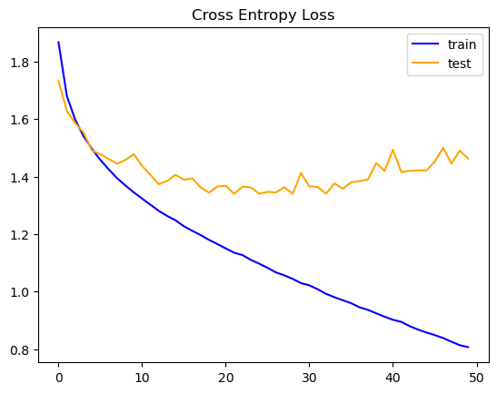

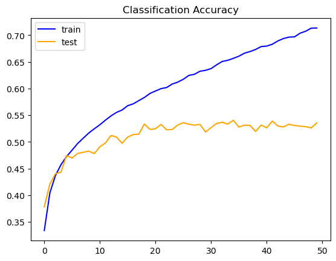

```
Czas wykonania: 0:06:11 sekund
```

```python
start_time = time.time()
run_test()
elapsed_time_secs = time.time() - start_time
msg = "Czas wykonania: %s sekund" % timedelta(seconds=round(elapsed_time_secs))
print(msg)
```

Jak widać powyższy model jest w stanie nauczyć się zestawu danych uczących, wykazując poprawę w zestawie danych uczących do conajmniej 30 epoki. Należy jednak także zauważyć, że model ten wykazuje nadmierne dopasowanie po 20-tej epoce patrząc na wyniki zbioru testowego. Wynik ten sugeruje, że ten prosty model wymaga pewnego uregulowania w celu rozwiązania nadmiernego dopasowania tj. overfittingu. Wyniki sugerują, że przydatne może być zbadanie technik, które spowolnią zbieżność (szybkość uczenia się) modelu. W celu zapobiegania overfitingowi można: **zastosować warstwę *Dropout()***

```python
#definicja modelu z warstwą Dropout
def define_model():
    model = Sequential()
    model.add(Flatten(input_shape=[32, 32,3]))
    model.add(Dense(300, activation='relu', kernel_initializer='he_uniform'))
    model.add(Dropout(0.2))
    model.add(Dense(100, activation='relu', kernel_initializer='he_uniform'))
    model.add(Dropout(0.2))
    model.add(Dense(10, activation='softmax'))

    opt = SGD(learning_rate=lr, momentum=0.9)
    model.compile(optimizer=opt, loss='categorical_crossentropy', metrics=['accuracy'])
    return model
```

```
Model: "sequential_1"
```

```
┏━━━━━━━━━━━━━━━━━━━━━━━━━━━━━━━━━┳━━━━━━━━━━━━━━━━━━━━━━━━┳━━━━━━━━━━━━━━━┓
┃ Layer (type)                    ┃ Output Shape           ┃       Param # ┃
┡━━━━━━━━━━━━━━━━━━━━━━━━━━━━━━━━━╇━━━━━━━━━━━━━━━━━━━━━━━━╇━━━━━━━━━━━━━━━┩
│ flatten_1 (Flatten)             │ (None, 3072)           │             0 │
├─────────────────────────────────┼────────────────────────┼───────────────┤
│ dense_3 (Dense)                 │ (None, 300)            │       921,900 │
├─────────────────────────────────┼────────────────────────┼───────────────┤
│ dropout (Dropout)               │ (None, 300)            │             0 │
├─────────────────────────────────┼────────────────────────┼───────────────┤
│ dense_4 (Dense)                 │ (None, 100)            │        30,100 │
├─────────────────────────────────┼────────────────────────┼───────────────┤
│ dropout_1 (Dropout)             │ (None, 100)            │             0 │
├─────────────────────────────────┼────────────────────────┼───────────────┤
│ dense_5 (Dense)                 │ (None, 10)             │         1,010 │
└─────────────────────────────────┴────────────────────────┴───────────────┘
```

```
 Total params: 953,010 (3.64 MB)
```

```
 Trainable params: 953,010 (3.64 MB)
```

```
 Non-trainable params: 0 (0.00 B)
```

```
> 54.070
```

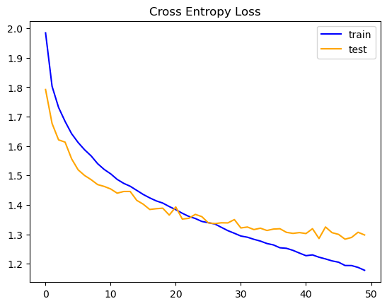

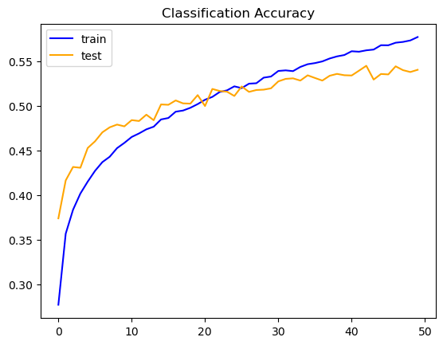

```
Czas wykonania: 0:06:23 sekund
```

```python
start_time = time.time()
run_test()
elapsed_time_secs = time.time() - start_time
msg = "Czas wykonania: %s sekund" % timedelta(seconds=round(elapsed_time_secs))
print(msg)
```

poprzez którą losowo usuwane są z sieci (z warstw wewnętrznych, czasami również wejściowych) pojedyncze neurony w trakcie uczenia. Ponieważ skomplikowane sieci, szczególnie dysponujące relatywnie niewielkimi ilościami danych uczących, mają tendencję do dokładnego dopasowywania się do danych, to taki sposób deregulacji zmusza je do uczenia w sposób bardziej zgeneralizowany.

Można także **zastosować regularyzację wag**

```python
#definicja modelu z regularyzacją
from tensorflow.keras import regularizers
def define_model():
    model = Sequential()
    model.add(Flatten(input_shape=[32, 32,3]))
    model.add(Dense(300, activation='relu', kernel_initializer='he_uniform', kernel_regularizer=regularizers.l2(0.001)))
    model.add(Dense(100, activation='relu', kernel_initializer='he_uniform', kernel_regularizer=regularizers.l2(0.001)))
    model.add(Dense(10, activation='softmax'))

    opt = SGD(learning_rate=lr, momentum=0.9)
    model.compile(optimizer=opt, loss='categorical_crossentropy', metrics=['accuracy'])
    return model
```

```
Model: "sequential_2"
```

```
┏━━━━━━━━━━━━━━━━━━━━━━━━━━━━━━━━━┳━━━━━━━━━━━━━━━━━━━━━━━━┳━━━━━━━━━━━━━━━┓
┃ Layer (type)                    ┃ Output Shape           ┃       Param # ┃
┡━━━━━━━━━━━━━━━━━━━━━━━━━━━━━━━━━╇━━━━━━━━━━━━━━━━━━━━━━━━╇━━━━━━━━━━━━━━━┩
│ flatten_2 (Flatten)             │ (None, 3072)           │             0 │
├─────────────────────────────────┼────────────────────────┼───────────────┤
│ dense_6 (Dense)                 │ (None, 300)            │       921,900 │
├─────────────────────────────────┼────────────────────────┼───────────────┤
│ dense_7 (Dense)                 │ (None, 100)            │        30,100 │
├─────────────────────────────────┼────────────────────────┼───────────────┤
│ dense_8 (Dense)                 │ (None, 10)             │         1,010 │
└─────────────────────────────────┴────────────────────────┴───────────────┘
```

```
 Total params: 953,010 (3.64 MB)
```

```
 Trainable params: 953,010 (3.64 MB)
```

```
 Non-trainable params: 0 (0.00 B)
```

```
> 54.400
```

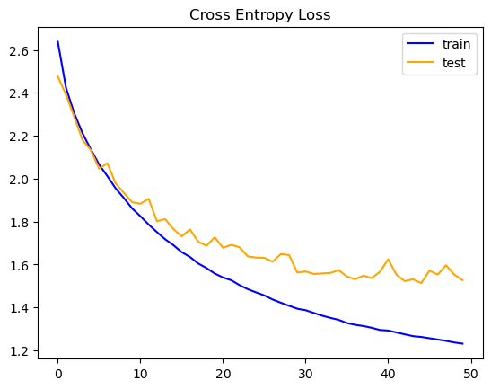

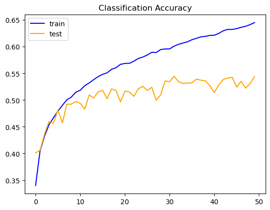

```
Czas wykonania: 0:06:50 sekund
```

```python
start_time = time.time()
run_test()
elapsed_time_secs = time.time() - start_time
msg = "Czas wykonania: %s sekund" % timedelta(seconds=round(elapsed_time_secs))
print(msg)
```

w tym przypadku regularyzacje $L2$ (znaną również jako zanik wagi), która dodaje "kwadrat wielkości" jako warunek kary do funkcji straty.

Można także **zastosować augmentację** czyli rozszerzenie zbioru danych uczących jak i umożliwia to modelowi poznanie tych samych ogólnych cech, choć w bardziej uogólniony sposób.

```python
def run_test2():
    trainX, trainY, testX, testY = load_dataset()
    trainX, testX = prep_pixels(trainX, testX)
    model = define_model()
    #augmentacja
    datagen = ImageDataGenerator(width_shift_range=0.1, height_shift_range=0.1, horizontal_flip=True)
    it_train = datagen.flow(trainX, trainY, batch_size=64)
    steps = int(trainX.shape[0] / 64)
    history = model.fit(it_train, steps_per_epoch=steps, epochs=epochs, validation_data=(testX, testY), verbose=0)
    _, acc = model.evaluate(testX, testY, verbose=0)
    print('> %.3f' % (acc * 100.0))
    summarize_diagnostics(history)

def define_model():
    model = Sequential()
    model.add(Flatten(input_shape=[32, 32,3]))
    model.add(Dense(300, activation='relu', kernel_initializer='he_uniform'))
    model.add(Dense(100, activation='relu', kernel_initializer='he_uniform'))
    model.add(Dense(10, activation='softmax'))

    opt = SGD(learning_rate=lr, momentum=0.9)
    model.compile(optimizer=opt, loss='categorical_crossentropy', metrics=['accuracy'])
    return model

    opt = SGD(learning_rate=lr, momentum=0.9)
    model.compile(optimizer=opt, loss='categorical_crossentropy', metrics=['accuracy'])
    return model
```

```python
from keras.preprocessing.image import ImageDataGenerator
start_time = time.time()
run_test2()
elapsed_time_secs = time.time() - start_time
msg = "Czas wykonania: %s sekund" % timedelta(seconds=round(elapsed_time_secs))
print(msg)
```

[output not shown]

Biorąc pod uwagę, że zbiór danych składa się z małych zdjęć obiektów, nie należy używać augmentacji, która zbyt mocno zniekształca obrazy, aby można było zachować i wykorzystać przydatne cechy obrazów.

Szeroko stosowaną techniką regularyzacji w uczeniu głębokim jest także **Wczesne zatrzymanie**, która polega na zatrzymaniu treningu, gdy wzrasta błąd uogólnienia.

# Zadania do wykonania (Do wyboru)

**Zadanie 1**

Przetestuj zachowanie się modelu przy zastosowaniu optymalizatora RMSprop, Adam i Nadam.

**Zadanie 2**

Do modelu dodaj warstwy Dropout i przeprowadź eksperymenty z wartościami 0.1, 0.3 i 0.5.

**Zadanie 3**

Czy dodanie regularyzacji wag w warstwach Dense (kernel_regularizer) o wartościach 0.01, 0.05 i 0.1 zmieni zachowanie modelu.

**Zadanie 4**

Zbadaj wpływ augmentacji na wynik końcowy modelu dodając *rotation_range* lub *shear_range* lub *zoom_range*.

**Zadanie 5**

Zbadaj wpływ głębokości modelu na jakość jego treningu.

## Rozwiązanie zadań 1 i 2 (2 wybrane)

Architektura modelu jest jak z przykładu (`Flatten -> Dense(300) -> Dense(100) -> Dense(10)`).

Eksperymenty wykonane na podzbiorze CIFAR-10: `12000` obrazów treningowych i `3000` testowych, przez `8` epok.

-> więc warianty są wykonywane w tych samych / podobnych warunkach (zależnie od modyfikacji).

```python
import os
import random
import time

import numpy as np
import tensorflow as tf
from tensorflow.keras.datasets import cifar10
from tensorflow.keras.layers import Dense, Dropout, Flatten
from tensorflow.keras.models import Sequential
from tensorflow.keras.optimizers import Adam, Nadam, RMSprop
from tensorflow.keras.utils import to_categorical

os.environ["TF_CPP_MIN_LOG_LEVEL"] = "2"

SEED = 42
EPOCHS = 8
BATCH_SIZE = 64
TRAIN_SAMPLES = 12000
TEST_SAMPLES = 3000


def set_seed(seed=SEED):
    random.seed(seed)
    np.random.seed(seed)
    tf.random.set_seed(seed)


def load_subset():
    (train_x, train_y), (test_x, test_y) = cifar10.load_data()
    train_x = train_x.astype("float32") / 255.0
    test_x = test_x.astype("float32") / 255.0
    train_y = to_categorical(train_y)
    test_y = to_categorical(test_y)

    rng = np.random.default_rng(SEED)
    train_idx = rng.choice(len(train_x), TRAIN_SAMPLES, replace=False)
    test_idx = rng.choice(len(test_x), TEST_SAMPLES, replace=False)
    return train_x[train_idx], train_y[train_idx], test_x[test_idx], test_y[test_idx]


def build_model(optimizer, dropout_rate=None):
    model = Sequential()
    model.add(Flatten(input_shape=[32, 32, 3]))
    model.add(Dense(300, activation="relu", kernel_initializer="he_uniform"))
    if dropout_rate is not None:
        model.add(Dropout(dropout_rate))
    model.add(Dense(100, activation="relu", kernel_initializer="he_uniform"))
    if dropout_rate is not None:
        model.add(Dropout(dropout_rate))
    model.add(Dense(10, activation="softmax"))
    model.compile(optimizer=optimizer, loss="categorical_crossentropy", metrics=["accuracy"])
    return model


def run_one(name, optimizer_factory, train_x, train_y, test_x, test_y, dropout_rate=None):
    set_seed()
    start = time.time()
    model = build_model(optimizer_factory(), dropout_rate=dropout_rate)
    history = model.fit(
        train_x,
        train_y,
        epochs=EPOCHS,
        batch_size=BATCH_SIZE,
        validation_data=(test_x, test_y),
        verbose=0,
    )
    test_loss, test_accuracy = model.evaluate(test_x, test_y, verbose=0)
    return {
        "wariant": name,
        "test_loss": test_loss,
        "test_accuracy": test_accuracy,
        "train_accuracy": history.history["accuracy"][-1],
        "best_val_accuracy": max(history.history["val_accuracy"]),
        "seconds": time.time() - start,
    }


train_x, train_y, test_x, test_y = load_subset()

wyniki_zadanie_1 = [
    run_one("RMSprop", lambda: RMSprop(learning_rate=0.001), train_x, train_y, test_x, test_y),
    run_one("Adam", lambda: Adam(learning_rate=0.001), train_x, train_y, test_x, test_y),
    run_one("Nadam", lambda: Nadam(learning_rate=0.001), train_x, train_y, test_x, test_y),
]

wyniki_zadanie_2 = [
    run_one("Dropout 0.1", lambda: Adam(learning_rate=0.001), train_x, train_y, test_x, test_y, dropout_rate=0.1),
    run_one("Dropout 0.3", lambda: Adam(learning_rate=0.001), train_x, train_y, test_x, test_y, dropout_rate=0.3),
    run_one("Dropout 0.5", lambda: Adam(learning_rate=0.001), train_x, train_y, test_x, test_y, dropout_rate=0.5),
]

print(f"Dane: {TRAIN_SAMPLES} próbek treningowych, {TEST_SAMPLES} testowych, epoki={EPOCHS}, batch_size={BATCH_SIZE}")
print()
print("Zadanie 1 - optymalizatory")
print("wariant        test_loss  test_accuracy  train_accuracy  best_val_accuracy  czas[s]")
for row in wyniki_zadanie_1:
    print(
        f"{row['wariant']:<12} {row['test_loss']:.4f}     {row['test_accuracy']:.4f}         "
        f"{row['train_accuracy']:.4f}          {row['best_val_accuracy']:.4f}             {row['seconds']:.2f}"
    )

print()
print("Zadanie 2 - Dropout")
print("wariant        test_loss  test_accuracy  train_accuracy  best_val_accuracy  czas[s]")
for row in wyniki_zadanie_2:
    print(
        f"{row['wariant']:<12} {row['test_loss']:.4f}     {row['test_accuracy']:.4f}         "
        f"{row['train_accuracy']:.4f}          {row['best_val_accuracy']:.4f}             {row['seconds']:.2f}"
    )
```

```
Dane: 12000 próbek treningowych, 3000 testowych, epoki=8, batch_size=64

Zadanie 1 - optymalizatory
wariant        test_loss  test_accuracy  train_accuracy  best_val_accuracy  czas[s]
RMSprop      1.8733     0.3467         0.4043          0.3467             12.67
Adam         1.6540     0.4047         0.4255          0.4047             14.16
Nadam        1.6628     0.4037         0.4549          0.4037             14.12

Zadanie 2 - Dropout
wariant        test_loss  test_accuracy  train_accuracy  best_val_accuracy  czas[s]
Dropout 0.1  1.7001     0.3890         0.3732          0.3890             14.60
Dropout 0.3  1.8793     0.3213         0.2767          0.3213             15.30
Dropout 0.5  2.0616     0.2463         0.1665          0.2563             14.26
```

**Wnioski - zadanie 1**

Dla testowanych optymalizatorów najlepszy wynik na zbiorze testowym uzyskał `Adam` (`test_accuracy=0.4047`, `test_loss=1.6540`). `Nadam` był bardzo blisko (`test_accuracy=0.4037`, `test_loss=1.6628`), więc w tym eksperymencie praktycznie nie dał zauważalnej przewagi nad Adamem. `RMSprop` wypadł słabiej, bo miał `test_accuracy=0.3467` i większy błąd `test_loss=1.8733`. Po 8 epokach na tym podzbiorze CIFAR-10 najrozsądniej wypada więc Adam.

**Wnioski - zadanie 2**

Dla warstw Dropout najlepszy wynik dała najmniejsza sprawdzana wartość, czyli `0.1` (`test_accuracy=0.3890`, `test_loss=1.7001`). Przy `Dropout=0.3` wynik spadł do `0.3213`, a przy `Dropout=0.5` do `0.2463`, więc większy dropout za mocno osłabiał uczenie modelu w tym ustawieniu. Widać to też po dokładności treningowej: dla `0.5` wyniosła tylko `0.1665`, czyli model miał problem nawet z dopasowaniem się do danych treningowych. W tym eksperymencie dropout nie poprawił wyniku względem Adama bez Dropoutu z zadania 1 (`0.4047`), ale `0.1` był najmniej szkodliwy z trzech sprawdzonych wartości.

Zbyt silny Dropout usuwa zbyt wiele istotnych połączeń między neuronami co osłabia wynik.

Ogólne założenie dla warstwy Dropout jest przeciwdziałanie overfittingowi i wsparcie generalizacji, ale w przypadku tego zadania Dropout ustawiony na 0.1 w zupełności wystarczył, a większe szkodziły wynikom.